# Introducción

Se utilizan los datos de RLadies Global para visualizar dónde se encuentran los distintos capítulos de RLadies en el mundo.

# Librerías

Se importan las librerías a utilizar:

```r
library(jsonlite)
library(tidyverse)
library(gt)
library(countrycode)
```

```r
N=5
```

# Datos

Los datos se obtienen del repositorio de RLadies Global:

```r
path <- 'https://raw.githubusercontent.com/rladies/rladies.github.io/main/data/meetup/chapters.json'
df <- as.data.frame(fromJSON(path))
```

```r
#df %>% write.csv('df_rladies_global.csv', row.names = FALSE)
df <- read.csv('df_rladies_global.csv') %>%
  mutate(country = countrycode(
    country_acronym, origin = 'iso2c', destination = 'country.name')
  ) %>%
  mutate(
    country = case_when(
      country=='United States' ~'USA',
      country=='United Kingdom'~'UK',
      TRUE ~ country
    )
  )
```

```r
df %>% glimpse()
```

```
## Rows: 227
## Columns: 11
## $ name            <chr> "R-Ladies Ljubljana", "R-Ladies Louisville", "R-Ladies…
## $ id              <int> 36618082, 36506652, 36506636, 36506535, 36506465, 3650…
## $ urlname         <chr> "rladies-ljubljana", "rladies-louisville-ky", "rladies…
## $ country_acronym <chr> "si", "us", "mx", "us", "nz", "ca", "eg", "gh", "us", …
## $ state           <chr> "", "KY", "", "FL", "", "NS", "", "", "OK", "HI", "", …
## $ city            <chr> "Ljubljana", "Louisville", "San Cristóbal de las Casas…
## $ members         <int> 53, 11, 8, 5, 13, 20, 7, 29, 32, 32, 180, 105, 3, 74, …
## $ lat             <dbl> 46.06, 38.25, 16.75, 27.42, -41.28, 44.64, 30.06, 5.56…
## $ lon             <dbl> 14.51, -85.78, -92.63, -80.45, 174.78, -63.57, 31.25, …
## $ timezone        <chr> "Europe/Belgrade", "America/New_York", "America/Mexico…
## $ country         <chr> "Slovenia", "USA", "Mexico", "USA", "New Zealand", "Ca…
```

# Tablas

```r
color_rladies = '#562457'
rladies_theme <- function(data, ...){
  data %>%
    tab_options(
      table.background.color = 'white',
      column_labels.background.color = "white",
      footnotes.background.color = "white",
      source_notes.background.color = "white",
      heading.background.color = "white",
      heading.align = "left"
    ) %>%
    tab_style(style = cell_text(color = color_rladies, size = px(32)),
              locations = cells_title("title")) %>%

    tab_style(locations = cells_source_notes(),
              style = list(
                cell_text(
                  font  = google_font(name = 'Raleway'),
                  size  = 'medium',
                  align = 'left',
                  color = '#666666'
                )
              )) %>%

    tab_style(locations = cells_footnotes(),
              style   = list(
                cell_text(
                  font  = google_font(name = 'Raleway'),
                  size  = 'medium',
                  align = 'left',
                  color = '#666666'
                )
              )) %>%

    # Opciones de la tabla
    tab_options(
      data_row.padding                  = px(0),
      table.border.top.style            = "hidden",
      table.border.bottom.style         = "hidden",
      table_body.border.top.style       = "solid",
      column_labels.border.bottom.style = "solid"
    )
}
```

## Tabla inicial

```r
df %>%
  slice_max(n=N, order_by=members) %>%
  gt() %>%
  tab_header(
    title = md('**RLadies**'),
    subtitle = glue::glue('Top {N} de capítulos con mayor cantidad de participantes')
  ) %>%
  rladies_theme()
```

**RLadies**

Top 5 de capítulos con mayor cantidad de participantes

| name | id | urlname | country_acronym | state | city | members | lat | lon | timezone | country |
| --- | --- | --- | --- | --- | --- | --- | --- | --- | --- | --- |
| R-Ladies New York | 20346526 | rladies-newyork | us | NY | New York | 2878 | 40.75 | -73.99 | America/New_York | USA |
| R-Ladies Washington D.C. | 21510971 | rladies-dc | us | DC | Washington | 2750 | 38.91 | -77.02 | America/New_York | USA |
| R-Ladies Santiago | 25039094 | rladies-scl | cl |  | Santiago | 2529 | -33.46 | -70.64 | America/Santiago | Chile |
| R-Ladies Puebla | 32426344 | rladies-puebla | mx |  | Puebla | 2422 | 19.05 | -98.22 | America/Mexico_City | Mexico |
| R-Ladies CDMX | 24820200 | rladies-cdmx | mx |  | México City | 2388 | 19.43 | -99.14 | America/Mexico_City | Mexico |

## Cantidad de participantes por capítulo por país

Se utiliza la función fmt_bins() para visualizar la cantidad de participantes por capítulo. Además, la función fmt_flag() permite incorporar las banderas de cada uno de los países.

```r
df %>%
  mutate(members_bin = cut(members,
                           breaks = scales::breaks_log(n = 10)(members))
                           #breaks=10)
         )  %>%
  arrange(country_acronym) %>%
  group_by(members_bin) %>%
  summarize(count = n(),
            countries = paste0(country_acronym, collapse = ",")) %>%
  arrange(desc(members_bin)) %>%
  gt() %>%
  fmt_flag(columns = countries) %>%
  fmt_bins(columns = members_bin,
           fmt = ~ fmt_integer(., suffixing = TRUE)) %>%
  tab_header(
    title = md('**RLadies**'),
    subtitle = 'Capítulos y cantidad de miembros por país'
  ) %>%
  rladies_theme()
```

**RLadies**

Capítulos y cantidad de miembros por país

members_bin

count

countries

1K–3K

28

[figure not shown]

500–1K

46

[figure not shown]

300–500

44

100–300

46

[figure not shown]

50–100

24

30–50

15

10–30

18

5–10

3

3–5

2

1–3

1

## ¿Dónde se encuentran los capítulos de RLadies?

Se cargan datos geográficos para visualizar mapas de cada uno de los países, dado que se cuenta con la ubicación (latitud-longitud) de cada capítulo.

```r
world <- map_data("world") %>%
  filter((subregion!='Alaska') | is.na(subregion)) %>%
  filter((region!='USA' | (region=='USA' & long<=-50)))
```

```r
selected_country <- 'Argentina'

ggplot()+
    geom_map(
      data = world %>% filter(region == selected_country),
      map = world %>% filter(region == selected_country),
      aes(long, lat, map_id = region),
      fill = 'lightgrey',
    ) +
    geom_point(
      data = df %>% filter(country == selected_country),
      mapping = aes(x = lon, y = lat, size=members),
      color = color_rladies,
      alpha=0.5
    ) +
    theme_void()+
    theme(
      legend.position = 'None',
      axis.text = element_blank(),
      plot.margin = unit(c(0, 0, 0, 0), "null")
    )
```

[output not shown]

## Agrupando por país

Mediante la función plot_map(), se obtiene un mapa para cada uno de los 5` países con más capítulos de RLadies:

```r
plot_map <- function(df, selected_country) {
  p <- ggplot() +
    geom_map(
      data = world %>% filter(region == selected_country),
      map = world %>% filter(region == selected_country),
      aes(long, lat, map_id = region),
      fill = 'lightgrey',
    ) +
    geom_point(
      data = df %>% filter(country == selected_country),
      mapping = aes(x = lon, y = lat, size=members),
      color = color_rladies,
      alpha=0.5
    ) +
    theme_void()+
    theme(
      legend.position = 'none',
      axis.text = element_blank(),
      plot.margin = unit(c(0, 0, 0, 0), "null")
    )

  return(p)
}
```

Dentro de la tabla {gt}, se visualiza cada uno de los mapas.

```r
table_data <- df %>%
  group_by(country) %>%
  summarise(
    n=n(),
    participantes_promedio = round(mean(members), 2),
    participantes_min = min(members),
    participantes_max = max(members)
  ) %>%
  arrange(desc(n)) %>%
  head(N) %>%
  mutate(plot = map(country, ~plot_map(selected_country=., df=df)))

table_data %>%
  gt() %>%
  text_transform(
    locations = cells_body(columns = plot),
    fn = function(x) {
      map(
        table_data$plot,
        gt::ggplot_image,
        height = px(100),
        aspect_ratio = 1
      )
    }
  ) %>%
  tab_header(
    title = md('**RLadies**'),
    subtitle = 'Capítulos y cantidad de participantes en Meetup por país'
  ) %>%
  cols_label(
    country = "Name",
    n = "N participantes",
    participantes_promedio = "N promedio",
    participantes_min = "N en el capítulo más chico",
    participantes_max = "N en el capítulo más grande",
    plot = "Ubicaciones"
  ) %>%

  cols_width(
    country ~ px(90),
    n ~ px(100),
    participantes_promedio ~ px(100),
    participantes_min ~ px(100),
    participantes_max ~ px(100),
    plot ~ px(200)
  ) %>%
  rladies_theme()
```

**RLadies**

Capítulos y cantidad de participantes en Meetup por país

Name

N participantes

N promedio

N en el capítulo más chico

N en el capítulo más grande

Ubicaciones

USA

54

546.56

4

2878

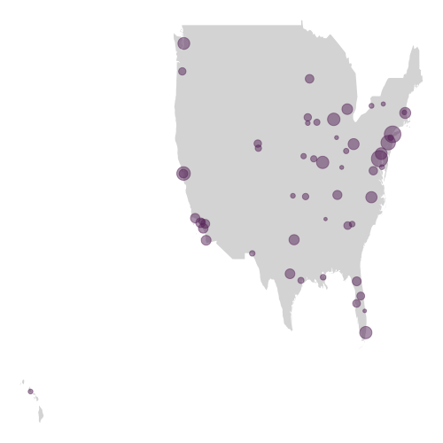

Brazil

17

406.94

12

1429

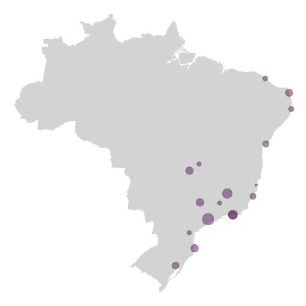

Mexico

15

649.27

3

2422

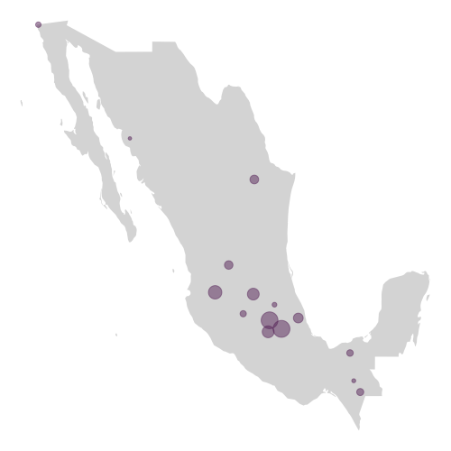

Argentina

10

325.50

31

1575

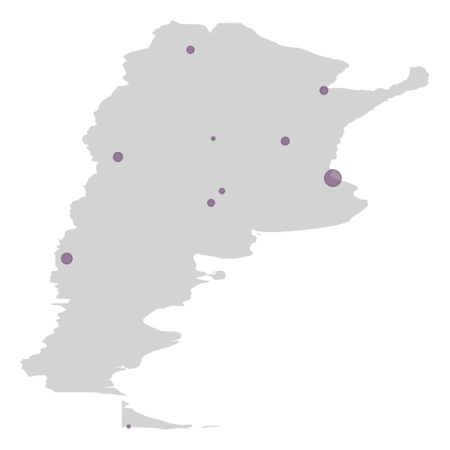

UK

10

428.10

30

1590

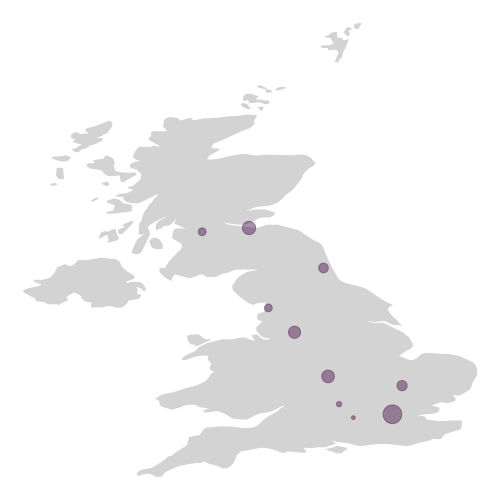